# data_tidying_project_01

Svetlana Tamitegama

5/11/2021

## Data Tidying Project

#### In order to do this, we will installing packages needed to manipulate the data, getting the data, saving the raw data, exploring the data, wrangling the data, merging the two data, and finally plotting the new data created.

### Get Data

[Data Set 1](https://data.world/retail/department-store-sales): Sales from the Retail Trade and Food Services Report from the US Census. This dataset only covers Department Stores, though the report covers a wide range of retail types. [1992-2016]

```r
#1992-2016
#https://data.world/retail/department-store-sales

GET("https://query.data.world/s/gdk7iwtlisq6vkktmybqqr7hjjty5s", write_disk(tf <- tempfile(fileext = ".xls")))
```

```
## Response [https://download.data.world/file_download/retail/department-store-sales/retail-trade-report-department-stores.xls?auth=eyJhbGciOiJIUzUxMiJ9.eyJzdWIiOiJwcm9kLXVzZXItY2xpZW50OnNoYW5lbGxpcyIsImlzcyI6ImFn….jBFlyy1aloE-EpeYyosD3iRaDPoY75DBqdh7suLoZxKcrsG8N5GtOiFb6sNMjTqqclsHX7P8RUw7T5sAArPbc…
##   Date: 2021-05-13 08:33
##   Status: 200
##   Content-Type: application/vnd.ms-excel
##   Size: 62.5 kB
## <ON DISK>  /var/folders/xn/2tgbbyhn02q_9cj5b7j2f5rw0000gn/T//RtmphAW7N8/file557a56ea83a9.xls
```

```r
df1 <- read_excel(tf)

#2009-2014
# https://data.world/garyhoov/retail-sales-growth
GET("https://query.data.world/s/py7kinxvyuxjpzwdjs2ti4wdmui6bi", write_disk(tf <- tempfile(fileext = ".xls")))
```

```
## Response [https://download.data.world/file_download/garyhoov/retail-sales-growth/US%20Retail%20Sales%20by%20Store%20Type%202009-2014.xls?auth=eyJhbGciOiJIUzUxMiJ9.eyJzdWIiOiJwcm9kLXVzZXItY2xpZW50OnNoYW5lbGxpcyIsImlzcyI6ImFn….NLTr571lKSZMKhmvIFFQGuoVeFVFr9DrQ7nxBO3LOcLTJUrKivBxWpUrcJcY8dxnkL4FlGba…
##   Date: 2021-05-13 08:33
##   Status: 200
##   Content-Type: application/vnd.ms-excel
##   Size: 169 kB
## <ON DISK>  /var/folders/xn/2tgbbyhn02q_9cj5b7j2f5rw0000gn/T//RtmphAW7N8/file557a3e69f8d3.xls
```

```r
df2 <- read_excel(tf)
```

```
## * `` -> ...2
## * `` -> ...3
## * `` -> ...4
## * `` -> ...5
## * `` -> ...6
## * ...
```

```r
## the the first row and make that the column names of the data frame
colnames(df2) <- df2[1,]
```

### Save Raw Data

```r
## use saveRDS() to save each object as a .rds file
saveRDS(df1, file = "df_department.rds")
saveRDS(df2, file = "df_retail.rds")
```

### Wrangle Data

#### The datasets being currently both in a wide data format will be wrangled into a more usable, long, data format that can be merged into a single data frame. The final data frame will have three columns: business, year, n.

#### Let’s save first the retail information df2 file as df_retail and wrangle it in a serie of manipulation using the pipe operator.

```r
## an example working with df2
## let's wrangle!
df_retail <- df2 %>%
  ## remove the r from the column names of df2
  magrittr::set_colnames(gsub("r","",df2[1,])) %>%
  ## add a new column called "business"
  mutate(business = gsub("[…]|[.]","",`Kind of business`)) %>%
  ## filter to include Retail sales or Department stores sales
  filter(grepl('Retail sales, total |Department stores', business)) %>%
  ## only look at columns with year information in them
  select(.,c(matches('19|20'),business)) %>%
  ## take year column and collapse them into a single column
  gather(., "year", "n", 1:(ncol(.)-1)) %>%
  ## make sure the count column `n` is numeric
  mutate(n=as.numeric(n)) %>%
  ## filter to only include the businesses we're interested in
  filter(business == "Retail sales, total "| business=="Department stores ")
```

#### Next df1 dataset is saved as df_department and transform as well from a wide data set to long one.

```r
## now, your turn!
## work with df1
df_department <- df1 %>%
  ## split Period column into one column called "month" and one called "year"
  separate(Period, into = c("month", "year"), extra = "drop", remove = FALSE) %>%
  ## add a column `value` which contains the
  ## information from the `Value (in millions)`
  mutate(value = gsub(" ", "_", `Value (in millions)`)) %>%
  ## group the data frame by the `year` column
  group_by(`year`) %>%
  ## Summarize the data by creating a new column
  ## call this column `n`
  ## have it contain the sum of the `value` column
  summarise(n = n(), n = sum(as.numeric(value))) %>%
  ### create a new column called `business`
  ## set the value of this column to  be "department stores"
  ## for the entire data set
  mutate(business = "Department stores") %>%
  ## reorder column names to be : business, year, n
  select(business, year, n)
```

#### As we’ve written a lot of code we will add this to Github using git add ., git commit and git push to add (all) the file changes to our GitHub repository

### Merging the data

#### Now that we wrangle df1 and df2 and saved these as df_retail and df_department we can merge them into a single data frame. For this we can bind their rows and create a new object df_total.

```r
## Now, combine the two data frames
df_total <- merge(x = df_department, y = df_retail, all = TRUE)
```

### Plotting the data

#### Now we can plot the data from the three data frames we created (df_retail, df_department and df_total) using the R package ggplot2.

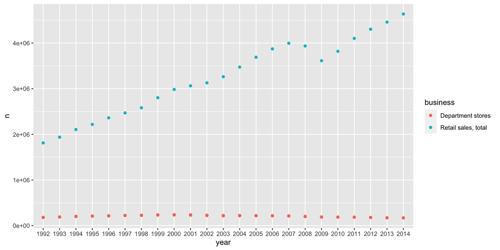

```r
## Plot Retail Sales data
ggplot(df_retail, aes(x=year,y=n,colour=business)) +
  geom_point()
```

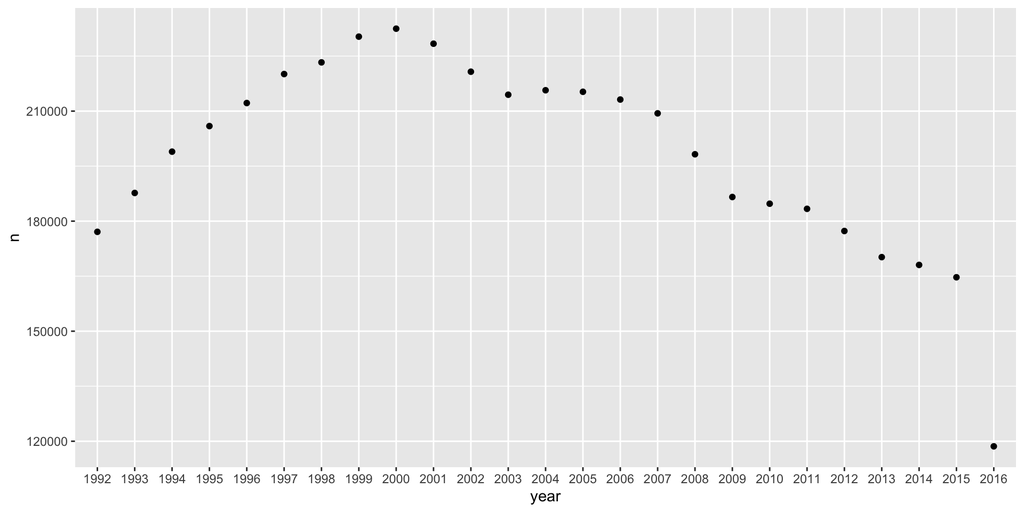

```r
## Plot Department Sales data
ggplot(df_department, aes(x=year,y=n)) +
  geom_point()
```

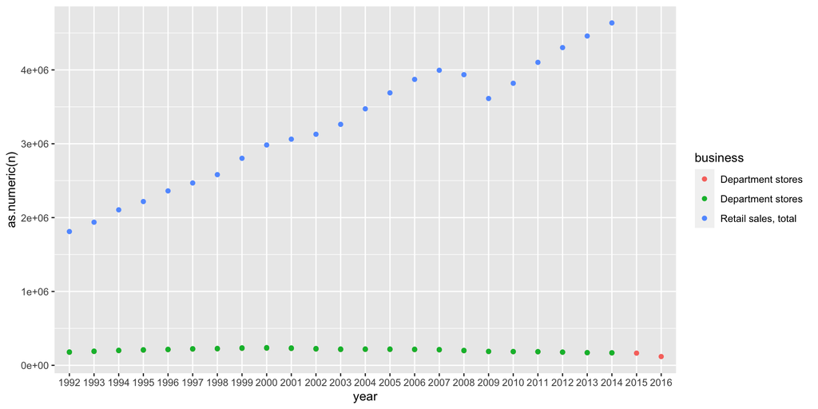

```r
## Plot Combined Data
ggplot(df_total, aes(x=year,y=as.numeric(n), colour=business)) +
  geom_point()
```

### Add Markdown text to .Rmd

### Knit the RMarkdown document

#### Then we knit this R Markdown document into an HTML document.

### Final push to GitHub

#### Now that we finalized our project, we’ll do one final push to GitHub. Add, commit and push the work to GitHub.

#### Then we navigate to our GitHub repository and look at the changes in the project.